# Score Computation Notebook

# Purpose

The purpose of this notebook is to use the raw travel time data to experiment with different methods of aggregation and score modeling.

## Import libraries

```r
library(tidyverse)
library(ggplot2)

# For pretty knitting
library(lemon)
knit_print.data.frame <- lemon_print
knit_print.tbl <- lemon_print
knit_print.summary <- lemon_print
```

## Import Scoring Functions

Note that the second scoring function is a much more realistic way of computing the worst case accessibility score. This is because we add 2* standard deviation in travel time to the average travel time as a way of getting a worst case travel time. The first method multiplies travel time with standard deviation which doesn’t exactly make sense since both those variables don’t have the same weight.

**The score output from this script will thus be the product of the second scoring function below**.

```r
source('Score_Functions.R')

# sum score function 1 : SUM [i..n] (1 / (traveltime_i * std_traveltime_i) + ... ))
# travel time and sd have equal weight (bad assumption) // don't use this method

# sum score function 2 : SUM [i..n] (1 / (traveltime_i + 2*std_traveltime_i) + ... ))
# travel time has more weight than sd, 2*sd is added as worst case scenario


# parameters for both:
# score_fxn(df, weight = FALSE, log_normalize_score = FALSE, normalize_df = FALSE, x=1, y=10)

# norm functions
# normalize_vec(vec, x=0.01, y=0.99, log = FALSE)
# normalize_df(df, x = 0.01, y = 0.99, log = FALSE)
```

```r
# function to plot score distributions by type
plot_densities <- function(score_frame1, score_frame2, titl1, titl2) {
  x <- score_frame1 %>%
        ggplot(aes(x = score, color = type)) +
        geom_density() +
        egg::theme_article() +
        theme(aspect.ratio = 0.3) +
        ggtitle(titl1)
  y <- score_frame2 %>%
        ggplot(aes(x = score, color = type)) +
        geom_density() +
        egg::theme_article() +
        theme(aspect.ratio = 0.3)+
        ggtitle(titl2)
  gridExtra::grid.arrange(x, y)
}
```

## Import data

```r
## Import raw Travel Time Matrix (ttm)
ttm <- read.csv('../../data/clean/ttm.csv')

n_origins <- 15197 # known origins
n_amenities <- 346 # known destinations from considered amenities

paste('Origins considered:', round(length(unique(ttm$fromId))/n_origins*100, 2), '%')
```

```
[1] "Origins considered: 94.38 %"
```

```r
paste('Destinations considered:', round(length(unique(ttm$toId))/n_amenities*100, 2), '%')
```

```
[1] "Destinations considered: 99.71 %"
```

```r
paste('Rows = ', nrow(ttm))
```

```
[1] "Rows =  4172482"
```

```r
# convert Ids from double to factor
ttm$fromId <- as.factor(ttm$fromId)
ttm$toId <- as.factor(ttm$toId)

summary(ttm[,3:4])
```

```
    avg_time         sd_time
 Min.   :  0.00   Min.   : 1.000
 1st Qu.: 50.59   1st Qu.: 1.847
 Median : 70.95   Median : 2.719
 Mean   : 71.70   Mean   : 3.235
 3rd Qu.: 93.46   3rd Qu.: 4.017
 Max.   :119.00   Max.   :35.355
```

## Data Wrangling

**Wrangling Notes:** - Remove skews and extreme values - Due to the diversity in amenity types (which all serve a unique cultural purpose), we’ll consider them independently for accessibility score computations. - Amenities which were interested in studying have already been filtered out in the ttm computation. They are the following: - Museums - Libraries - Galleries - Theatres

**Import and join amenity types**

```r
target_amenities <- c('gallery', 'museum', 'library or archives', 'theatre/performance and concert hall')
amenities <- read.csv('../../data/clean/vancouver_facilities_2.csv') %>% filter(type %in% target_amenities)

# preview original
sample_n(amenities, 3)
```

| id | lat | lon | type | name | city | city_id |
| --- | --- | --- | --- | --- | --- | --- |
| 9567 | 49.329034 | -123.16538 | library or archives | West Vancouver Memorial Library | West Vancouver | 5915055 |
| 8922 | 49.21419488 | -122.9031079 | theatre/performance and concert hall | The Bernie Legge Theatre | New Westminster | 5915029 |
| 3171 | 49.2643788 | -123.2543722 | theatre/performance and concert hall | Dorothy Somerset Studio Theatre | Greater Vancouver A | 5915020 |

```r
# clean
amenities <- amenities[,c(1,4)] # only need id and type columns
amenities$id <- as.factor(amenities$id)     # convert to factor
amenities$type <- as.factor(amenities$type) # convert to factor

# preview clean
sample_n(amenities, 3)
```

| id | type |
| --- | --- |
| 4288 | museum |
| 2644 | museum |
| 1930 | library or archives |

```r
# view summary
amenities %>% group_by(type) %>% summarise(count = n()) %>% arrange(desc(count))
```

| type | count |
| --- | --- |
| gallery | 99 |
| museum | 92 |
| library or archives | 88 |
| theatre/performance and concert hall | 75 |

```r
ttm <- ttm %>% left_join(amenities, by = c('toId' = 'id'))

names(ttm)[names(ttm) == 'avg_unique_time'] <- "avg_time"
names(ttm)[names(ttm) == 'sd_unique_time'] <- "sd_time"

summary(ttm[,3:4])
```

```
    avg_time         sd_time
 Min.   :  0.00   Min.   : 1.000
 1st Qu.: 50.59   1st Qu.: 1.847
 Median : 70.95   Median : 2.719
 Mean   : 71.70   Mean   : 3.235
 3rd Qu.: 93.46   3rd Qu.: 4.017
 Max.   :119.00   Max.   :35.355
```

```r
sample_n(ttm, 5)
```

| fromId | toId | avg_time | sd_time | type |
| --- | --- | --- | --- | --- |
| 59153618024 | 7517 | 89.05128 | 2.723665 | museum |
| 59150910002 | 2782 | 41.79487 | 1.417550 | gallery |
| 59151121005 | 9332 | 75.64103 | 2.699778 | museum |
| 59151061002 | 9244 | 86.05128 | 3.308273 | museum |
| 59151102001 | 8777 | 71.20513 | 2.330343 | gallery |

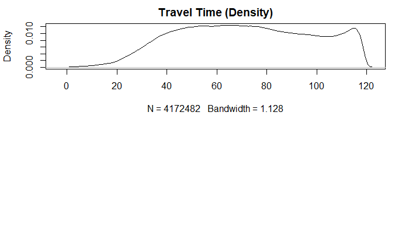

```r
par(mfrow = c(2,1))
plot(density(ttm[,3]), main = 'Travel Time (Density)')
plot(density(ttm[,4]), main = 'Std Dev of Travel Time (Density)')
```

**Replace travel times less than 5 minutes to 5 minutes**

This is done to prevent infinity values in the scoring. Normalization will be done to prevent zero values but it still creates a largely skewed score if we include travel times that approach zero. 5 minutes is also a realistic time window for any travel time that may take 0 - 5 minutes.

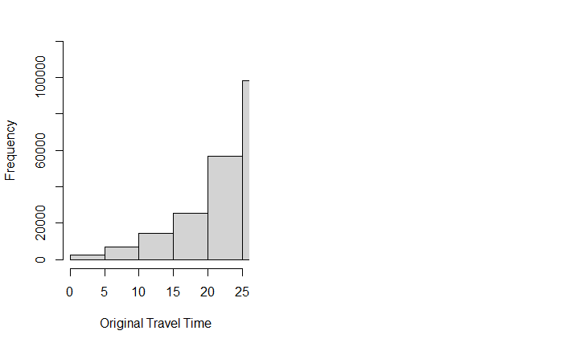

```r
par(mfrow = c(1, 2))

hist((ttm$avg_time), xlab = 'Original Travel Time', main = '',
     xlim = c(0, 25), ylim = c(0, 120000))

# set travel times <5 minutes to 5 minutes
min_5min <- pmax(ttm$avg_time, 5)
hist(min_5min, xlab = 'Original Travel Time', main = '',
     xlim = c(0, 25), ylim = c(0, 120000))
```

```r
ttm$avg_time <- min_5min
```

**Correct Outliers in Standard Deviation**

This will be important to prevent skew amplification in the score computation.

We can use a log to correct the skew however this will make the values incomparable to the travel time. As such we’ll just clip values on the extreme by setting them to a max of 10 minutes. Notice the distributions in both cases is the same.

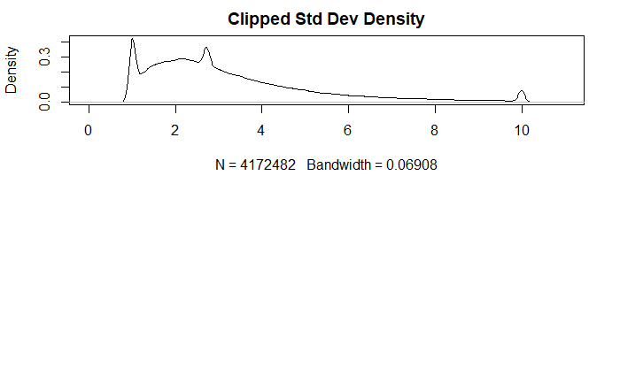

```r
par(mfrow = c(2, 1))

# correct standard deviations beyond 10 minutes
# taking the log will make the sd somewhat incomparable to the travel time
temp1 <- ttm$sd_time
temp1[temp1 > 10] <- 10
plot(density(temp1), main = 'Clipped Std Dev Density', xlim = c(0,11))

# using log + 1 to prevent values from being too close to zero
temp2 <- log(ttm$sd_time) +1
plot(density(temp2), main = 'Log+1 Std Dev Density', xlim = c(0,11))
```

```r
# set sd_unique_time to be the Log+1 corrected values
ttm$sd_time <- temp1
```

## Add Amenity Weights

```r
# Import weight
dest_wts <- read.csv('../../data/amenity_weight/poi_index.csv')

# clean
dest_wts <- dest_wts[, c(6,7)] # keep weight, id
names(dest_wts) <- c('weight', 'id')
dest_wts$id <-  as.factor(dest_wts$id)
head(dest_wts)
```

|  | weight | id |
| --- | --- | --- |
| 1 | 0.4715253 | 2292 |
| 2 | 0.6862229 | 2692 |
| 3 | 0.6713151 | 4546 |
| 4 | 0.5692166 | 6749 |
| 5 | 0.8031763 | 7153 |
| 6 | 0.5694037 | 7806 |

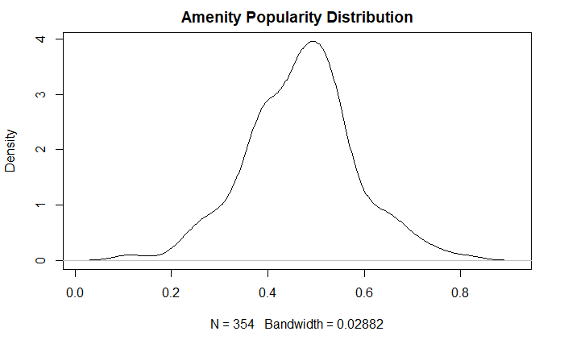

```r
# see weight distribution
plot(density(dest_wts$weight), main = 'Amenity Popularity Distribution')
```

```r
# join column
ttm_wts <- left_join(ttm, dest_wts, by = c('toId'='id'))

# If any weights are undefined replace with 1
ttm_wts$weight[is.na(ttm_wts$weight)] <- 1

head(ttm_wts)
```

|  | fromId | toId | avg_time | sd_time | type | weight |
| --- | --- | --- | --- | --- | --- | --- |
| 1 | 59150004004 | 10 | 99.76316 | 5.364721 | museum | 0.4829706 |
| 2 | 59150004004 | 15 | 72.48718 | 3.401794 | museum | 0.2669118 |
| 3 | 59150004004 | 157 | 96.69231 | 3.001349 | gallery | 0.5354125 |
| 4 | 59150004004 | 1759 | 106.82051 | 4.388213 | museum | 0.3589059 |
| 5 | 59150004004 | 1760 | 46.58974 | 2.642944 | gallery | 0.4060835 |
| 6 | 59150004004 | 1822 | 76.64103 | 3.990035 | museum | 0.6582380 |

```r
NA
NA
```

## Sum Scoring Method = 1/(mean+2sd)

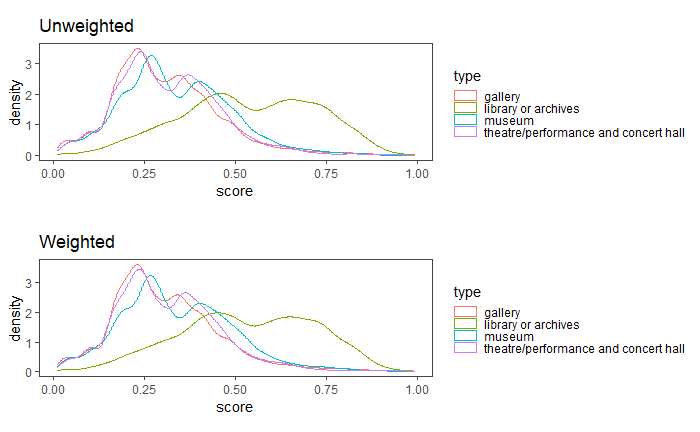

```r
# Score we care about
ttm_scores <- sum_score_fxn_2(ttm_wts, weight = FALSE)
ttm_wtd_scores <- sum_score_fxn_2(ttm_wts, weight = TRUE)
plot_densities(ttm_scores, ttm_wtd_scores, 'Unweighted', 'Weighted')
```

*Experimental cell for comparing different score distributions with different normalization conditions*

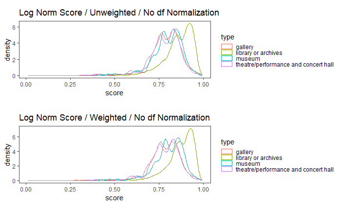

```r
## WITH score log normalization

# scores without df normalization
ttm_scores_1 <- sum_score_fxn_2(ttm_wts, weight = FALSE, log_normalize_score = TRUE,
                            normalize_df = FALSE)

ttm_wtd_scores_1 <- sum_score_fxn_2(ttm_wts, weight = TRUE, log_normalize_score = TRUE,
                            normalize_df = FALSE)

# scores with [1 - 100] df normalization
ttm_scores_2 <- sum_score_fxn_2(ttm_wts, weight = FALSE, log_normalize_score = TRUE,
                            normalize_df = TRUE, x = 1, y = 10)

ttm_wtd_scores_2 <- sum_score_fxn_2(ttm_wts, weight = TRUE, log_normalize_score = TRUE,
                            normalize_df = TRUE, x = 1, y = 10)

# scores with [0 - 1] df normalization
ttm_scores_3 <- sum_score_fxn_2(ttm_wts, weight = FALSE, log_normalize_score = TRUE,
                            normalize_df = TRUE, x = 0.01, y = 0.99)

ttm_wtd_scores_3 <- sum_score_fxn_2(ttm_wts, weight = TRUE, log_normalize_score = TRUE,
                            normalize_df = TRUE, x = 0.01, y = 0.99)

plot_densities(ttm_scores_1, ttm_wtd_scores_1, 'Log Norm Score / Unweighted / No df Normalization', 'Log Norm Score / Weighted / No df Normalization')
```

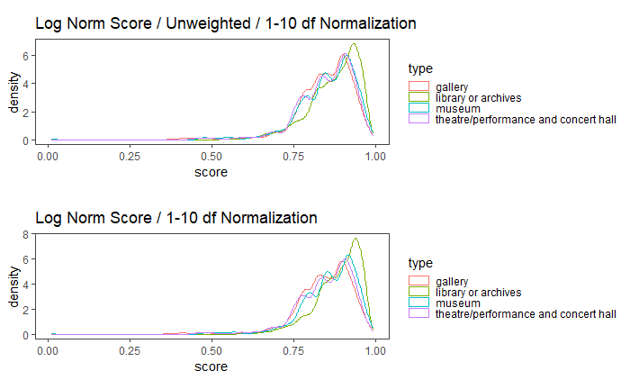

```r
plot_densities(ttm_scores_2, ttm_wtd_scores_2, 'Log Norm Score / Unweighted / 1-10 df Normalization', 'Log Norm Score / 1-10 df Normalization')
```

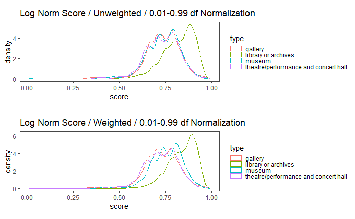

```r
plot_densities(ttm_scores_3, ttm_wtd_scores_3, 'Log Norm Score / Unweighted / 0.01-0.99 df Normalization', 'Log Norm Score / Weighted / 0.01-0.99 df Normalization')
```

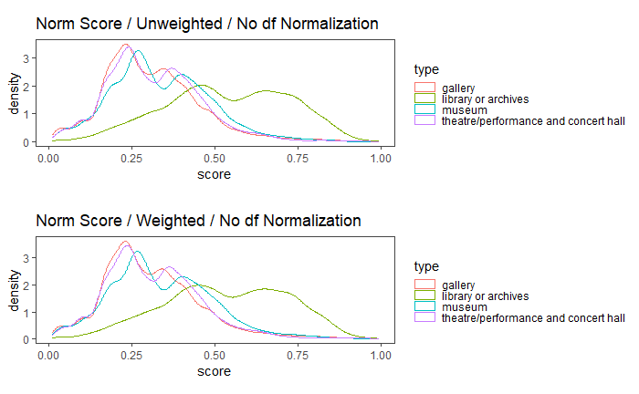

```r
## WITHOUT score log normalization

# scores without df normalization
ttm_scores_4 <- sum_score_fxn_2(ttm_wts, weight = FALSE, log_normalize_score = FALSE,
                            normalize_df = FALSE)

ttm_wtd_scores_4 <- sum_score_fxn_2(ttm_wts, weight = TRUE, log_normalize_score = FALSE,
                            normalize_df = FALSE)

# scores with [1 - 100] df normalization
ttm_scores_5 <- sum_score_fxn_2(ttm_wts, weight = FALSE, log_normalize_score = FALSE,
                            normalize_df = TRUE, x = 1, y = 10)

ttm_wtd_scores_5 <- sum_score_fxn_2(ttm_wts, weight = TRUE, log_normalize_score = FALSE,
                            normalize_df = TRUE, x = 1, y = 10)

# scores with [0 - 1] df normalization
ttm_scores_6 <- sum_score_fxn_2(ttm_wts, weight = FALSE, log_normalize_score = FALSE,
                            normalize_df = TRUE, x = 0.01, y = 0.99)

ttm_wtd_scores_6 <- sum_score_fxn_2(ttm_wts, weight = TRUE, log_normalize_score = FALSE,
                            normalize_df = TRUE, x = 0.01, y = 0.99)

plot_densities(ttm_scores_4, ttm_wtd_scores_4, 'Norm Score / Unweighted / No df Normalization', 'Norm Score / Weighted / No df Normalization')
```

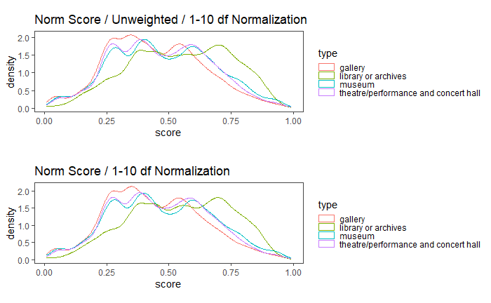

```r
plot_densities(ttm_scores_5, ttm_wtd_scores_5, 'Norm Score / Unweighted / 1-10 df Normalization', 'Norm Score / 1-10 df Normalization')
```

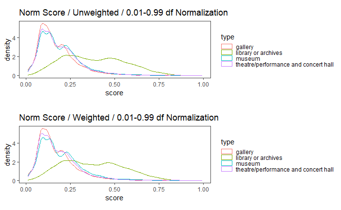

```r
plot_densities(ttm_scores_6, ttm_wtd_scores_6, 'Norm Score / Unweighted / 0.01-0.99 df Normalization', 'Norm Score / Weighted / 0.01-0.99 df Normalization')
```

```r
# scores with [0.01 - 0.99] df normalization

ttm_scores2 <- sum_score_fxn(ttm_wts,
                            weight = FALSE,
                            log_normalize_score = TRUE,
                            normalize_df = TRUE, x = 0.01, y = 0.99)

ttm_wtd_scores2 <- sum_score_fxn(ttm_wts,
                            weight = TRUE,
                            log_normalize_score = TRUE,
                            normalize_df = TRUE, x = 0.01, y = 0.99)

plot_densities(ttm_scores2, ttm_wtd_scores2, 'Unweighted Scores', 'Weighted Scores')
```

[output not shown]

## Sum Scoring for the Nearest 1, 2, or 3 Amenities

### Filtering only nearest 1, 2, 3 rows

*Note that for nearest 1, the sum is the value itself.*

```r
# Keep only the nearest 1, 2, or 3 travel times for each dissemination block

nearest_1_ttm <- ttm_wts %>%
                  group_by(fromId, type) %>%
                  summarise(avg_time = min(avg_time),
                            sd_time = sd_time[which.min(avg_time)],
                            weight = weight[which.min(avg_time)])

nearest_2_ttm <- ttm_wts %>%
                  group_by(fromId, type) %>%
                  summarise(avg_time = na.omit(sort(avg_time)[1:2]),
                            sd_time = sd_time[which(avg_time == sort(avg_time)[1:2])],
                            weight = weight[which(avg_time == sort(avg_time)[1:2])])

nearest_3_ttm <- ttm_wts %>%
                  group_by(fromId, type) %>%
                  summarise(avg_time = na.omit(sort(avg_time)[1:3]),
                            sd_time = sd_time[which(avg_time == sort(avg_time)[1:3])],
                            weight = weight[which(avg_time == sort(avg_time)[1:3])])
```

### Scoring as done above with = 1/(mean+2sd)

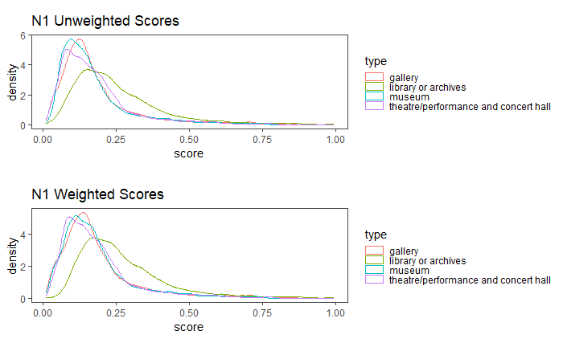

```r
# scores by nearest amenities

n1_ttm_score <- sum_score_fxn_2(nearest_1_ttm, weight = FALSE)
n1_wt_ttm_score <- sum_score_fxn_2(nearest_1_ttm, weight = TRUE)

n2_ttm_score <- sum_score_fxn_2(nearest_2_ttm, weight = FALSE)
n2_wt_ttm_score <- sum_score_fxn_2(nearest_2_ttm, weight = TRUE)

n3_ttm_score <- sum_score_fxn_2(nearest_3_ttm, weight = FALSE)
n3_wt_ttm_score <- sum_score_fxn_2(nearest_3_ttm, weight = TRUE)


plot_densities(n1_ttm_score, n1_wt_ttm_score, 'N1 Unweighted Scores', 'N1 Weighted Scores')
```

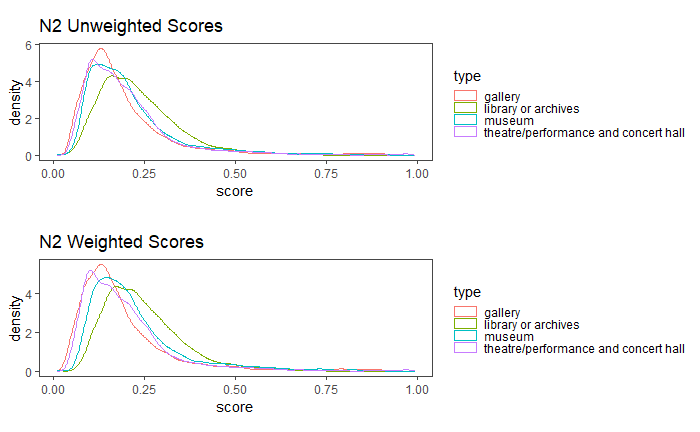

```r
plot_densities(n2_ttm_score, n2_wt_ttm_score, 'N2 Unweighted Scores', 'N2 Weighted Scores')
```

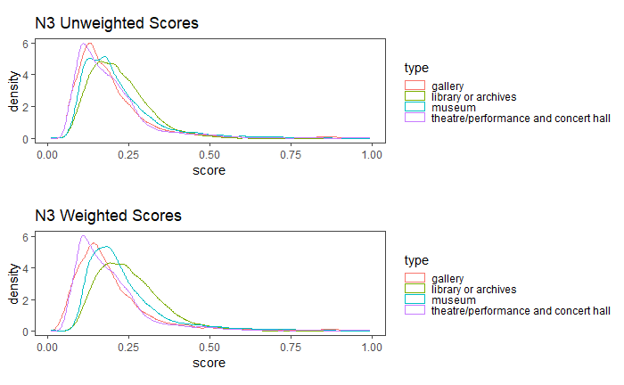

```r
plot_densities(n3_ttm_score, n3_wt_ttm_score, 'N3 Unweighted Scores', 'N3 Weighted Scores')
```

## Exporting all Score Sets

```r
## Add a weight status column for each score frame

ttm_scores$weight <- as.factor('no')
ttm_wtd_scores$weight <- as.factor('yes')

n1_ttm_score$weight <- as.factor('no')
n1_wt_ttm_score$weight <- as.factor('yes')

n2_ttm_score$weight <- as.factor('no')
n2_wt_ttm_score$weight <- as.factor('yes')

n3_ttm_score$weight <- as.factor('no')
n3_wt_ttm_score$weight <- as.factor('yes')


## Add nearest_n column for each score frame

ttm_scores$nearest_n <- as.factor('all')
ttm_wtd_scores$nearest_n <- as.factor('all')

n1_ttm_score$nearest_n <- as.factor('1')
n1_wt_ttm_score$nearest_n <- as.factor('1')

n2_ttm_score$nearest_n <- as.factor('2')
n2_wt_ttm_score$nearest_n <- as.factor('2')

n3_ttm_score$nearest_n <- as.factor('3')
n3_wt_ttm_score$nearest_n <- as.factor('3')


## Combine into a long dataframe
all_scores <- list(ttm_scores, ttm_wtd_scores,
                   n1_ttm_score, n1_wt_ttm_score,
                   n2_ttm_score, n2_wt_ttm_score,
                   n3_ttm_score, n3_wt_ttm_score)

long_scores <- data.table::rbindlist(all_scores) %>% arrange(fromId)


## Re-Order columns
long_scores <- long_scores[, c(1, 2, 4, 5, 3)]


## Add Block Population Data

db_info <- read.csv('../../data/clean/vancouver_db.csv')[1:2]
# convert to factor
db_info$id <- as.factor(db_info$id)
# remove commas in character numeric column
db_info$pop <- str_replace_all(db_info$pop, ',', '')
db_info$pop <- as.numeric(db_info$pop)

long_scores <- left_join(long_scores, db_info, by = c('fromId'='id'))
```

We’re almost done. All zones would ideally have 32 different scores based on possible schemes.

2 weight options * 4 amenity options * 4 nearest options = 32

Many zones however don’t have any routes, such as provincial parks which aren’t linked to via transit. To visualize them in the data we need to attribute these cases an NA value. Since these rows are missing we’ll use the following code to re-add those NA values.

```r
# check for the inconsistency in values
counted <- long_scores %>% group_by(fromId) %>% summarize(n = n()) %>% arrange(n)
#plot(counted$n, type = 'l', xlim = c(0, 1000))


unique_fromIds <- length(unique(long_scores$fromId))
N <- unique_fromIds*32

paste('Unique Blocks: ', unique_fromIds)
```

```
[1] "Unique Blocks:  14343"
```

```r
paste(nrow(long_scores), 'of', N, 'rows filled =', round((nrow(long_scores) / N)*100, 2),'%')
```

```
[1] "458256 of 458976 rows filled = 99.84 %"
```

```r
paste(N-nrow(long_scores), 'to fill.')
```

```
[1] "720 to fill."
```

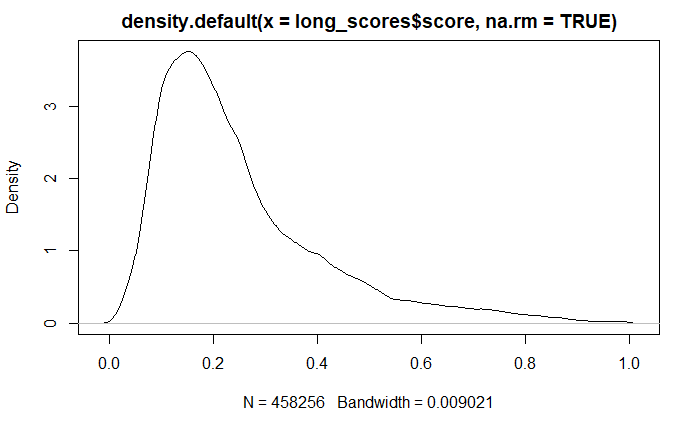

```r
# count fromId occurences
n_counts <- long_scores %>% group_by(fromId) %>% mutate(n = n())

# array of IDs that don't meet the 32 requirement
id_arr <- array(unique(n_counts[n_counts$n < 32, ]$fromId))

# function for NA grid expansion
NA_grid_expander <- function(id, df) {
  all_ams <- c('theatre/performance and concert hall', 'museum', 'library or archives', 'gallery')
  # get missing amenities
  missing_ams <- setdiff(all_ams, unique(df$type[df$fromId == id]))
  # population
  pop <- unique(df$pop[df$fromId == id])
  # create NA rows to append via expand.grid
  # (creates a row for every factor combination)
  NA_rows <- expand.grid('fromId' = id,
                     'type' = missing_ams,
                     'weight' = c('yes', 'no'),
                     'nearest_n' = c('all', '1', '2', '3'),
                     'score' = NA, 'pop' = pop, stringsAsFactors = TRUE)
  NA_rows
}

filler_rows <- data.table::rbindlist(apply(id_arr, MARGIN = 1, FUN = NA_grid_expander, df = long_scores))

long_scores <- data.table::rbindlist(list(long_scores_test, filler_rows)) %>% arrange(fromId, type, nearest_n, weight)

plot(density(long_scores$score, na.rm = TRUE))
```

```r
NA
NA
```

```r
## Export
write.csv(long_scores, '../../data/score_sets/newest_long_scores.csv', row.names = FALSE)
```

# Old Notes ~ Ignore or reuse later

| Name | Function | Notes | Assumptions |
| --- | --- | --- | --- |
| Unweighted Naive | number of accessible points / (mean transit time * mean standard deviation in transit time) | Mean transit time to all accessible destinations | Assumes that accessibility is defined by access to all amenities |
| Weighted Naive | popularity weighted accessible points / (mean transit time * mean standard deviation in transit time) | Mean transit time to all accessible destinations | Assumes that accessibility is defined by access to all amenities and that amenity popularity defines significance of an accessible amenity |
| Unweighted Sum | 1 / (nearest amenity transit time + standard deviation in nearest transit time) | Only considers the nearest 1 to 3 amenities of a certain category. Sum is used to prevent skewing of data (difference(1/(0.01*0.01) and 1/(6*6)) >>> difference(1/(0.01+0.01) and 1/(6+6))) | Assumes accessibility only defined by access to the nearest amenity type |
| Joseph Unweighted Sum | sum(1 / (normalized_transit_time_i*normalized_sd_time_i)) | Sums the transit times as opposed to taking the mean, then normalizes the scores. |  |